# Data Science II - Assignment

# Result analysis and visualization

To conclude, I was able to analyze the data given here and come to some conclusions that make sense and some that make less sense. Below I plot again the errors of each of my models for each target variable (predictions-actual values) and we see graphs that support my models and the inconsistency that I also found in them.

The schools target variable had the worst fitting model, and this makes sense looking at how there are some very big outliers in the data it seems, resulting in more errors generally that for the other 2 target variables. Similarly in the transport salespoints target variable there are much less outliers in the errors showing a better fit for the model.

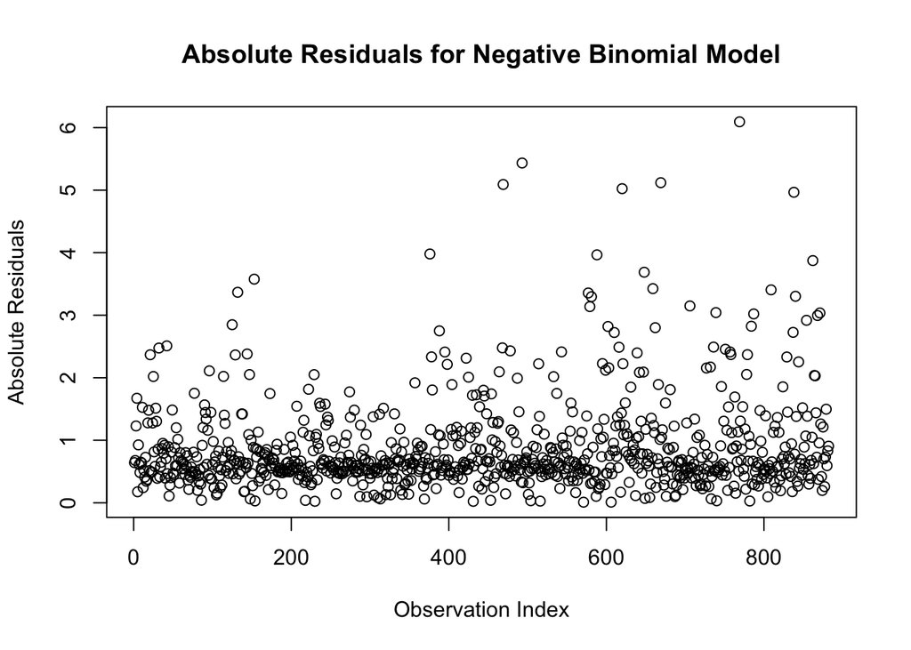

```r
knitr::opts_chunk$set(echo = TRUE)
negbin_schools_plot <- plot(abs(test.data_schools$n_schools - negbin_predictions),
                    xlab = "Observation Index",
                    ylab = "Absolute Residuals",
                    main = "Absolute Residuals for Negative Binomial Model")
```

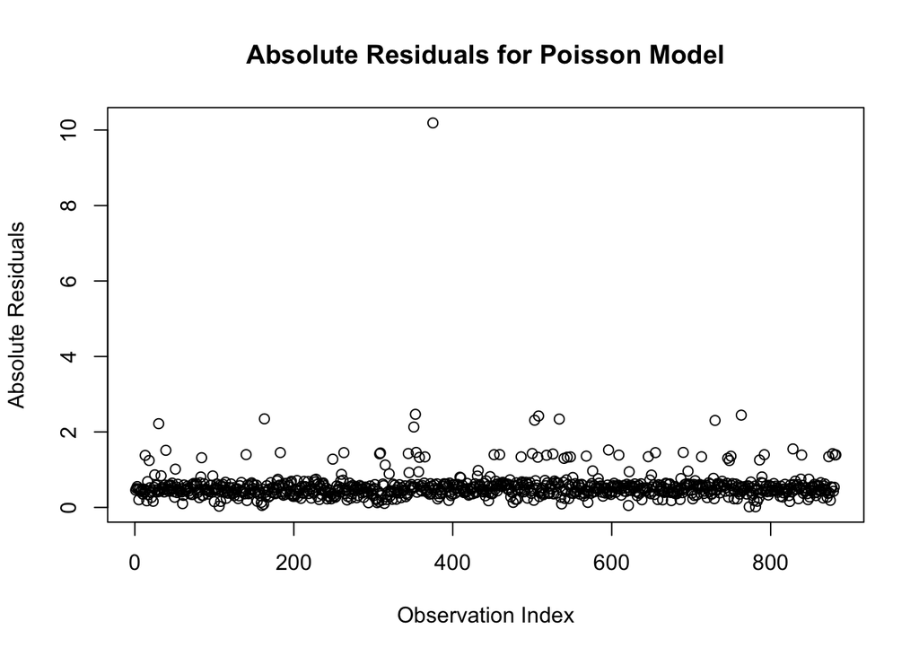

```r
poisson_pharmacies_plot <- plot(abs(test.data_pharmacies$n_pharmacies - poisson_predictions2),
                               xlab = "Observation Index",
                    ylab = "Absolute Residuals",
                    main = "Absolute Residuals for Poisson Model")
```

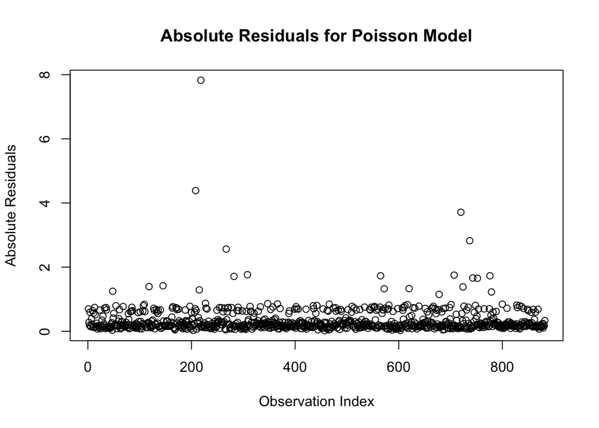

```r
poisson_transport_plot <- plot(abs(test.data_transportation$n_transport_salespoints -poisson_predictions3),
                                xlab = "Observation Index",
                                ylab = "Absolute Residuals",
                                main = "Absolute Residuals for Poisson Model")
```

Next I see how the odds of there being enough of each facility change with a change in the number of each type of facility. I visualize this using the logistic regressions done above and each of the target variables and the scores that were assigned above to deem whether there are ‘enough’ of each type of facility.

In these maps we get quite expectable results, for example in the number of schools example, the less schools you have in a census section, the lower the probability is that there are enough schools in this section. As we go to sections with higher amounts of schools, we see the probabilities converge to 1, so to the probability that there are enough schools being 1. This makes sense, however for this it is important to note that the metric that I used to establish what is ‘enough’ and what is not, is based on the regression models used earlier in the analysis. It could have also been interesting to evaluate the metric of ‘enough’ using the population, area or city size as parameters. We see a similar effect with the pharmacies. However with the transport salespoints we see the opposite effect, where the probability goes down as you add more of the places.

Here it may make sense that this happens because the places with the most amount of transport salespoints are big cities with lots of tourists for example that may need these salespoints more than locals.

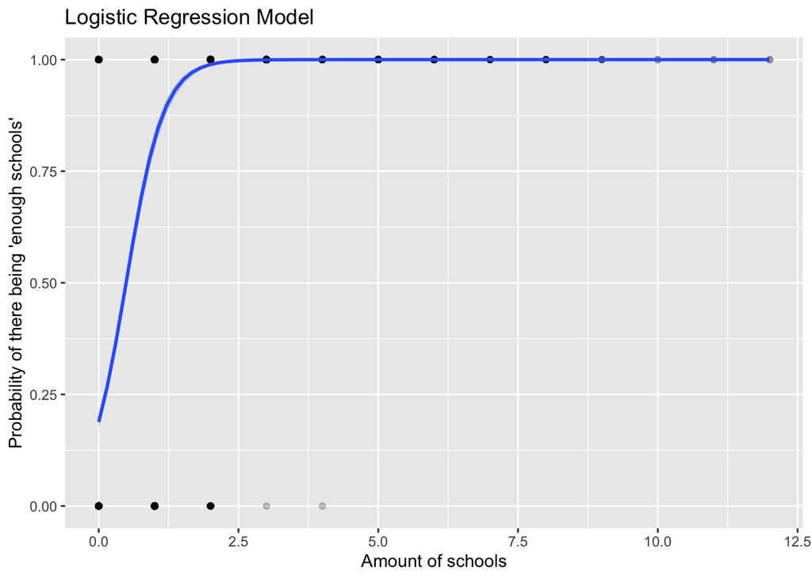

```r
knitr::opts_chunk$set(echo = TRUE)
#n_schools logistic regression on the score
df_n_school_2 %>%
  mutate(prob = ifelse(score == "0", 1, 0)) %>%
  ggplot(aes(n_schools , prob)) +
  geom_point(alpha = 0.2) +
  geom_smooth(method = "glm", method.args = list(family = "binomial")) +
  labs(
    title = "Logistic Regression Model",
    x = "Amount of schools",
    y = "Probability of there being 'enough schools'"
    )
```

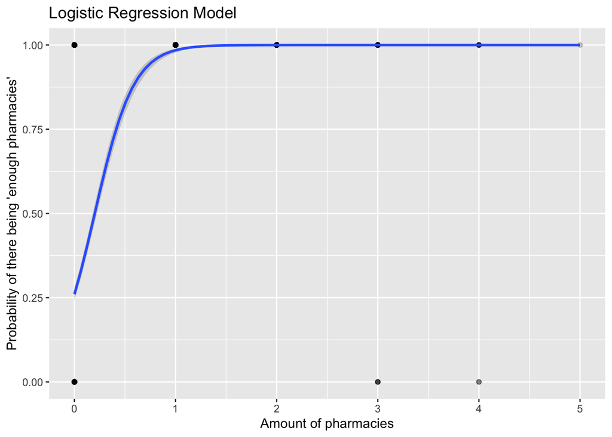

```r
#n_pharmacies logistic regression on the score
df_n_pharmacies_2 %>%
  mutate(prob = ifelse(score == "0", 1, 0)) %>%
  ggplot(aes(n_pharmacies , prob)) +
  geom_point(alpha = 0.2) +
  geom_smooth(method = "glm", method.args = list(family = "binomial")) +
  labs(
    title = "Logistic Regression Model",
    x = "Amount of pharmacies",
    y = "Probability of there being 'enough pharmacies'"
    )
```

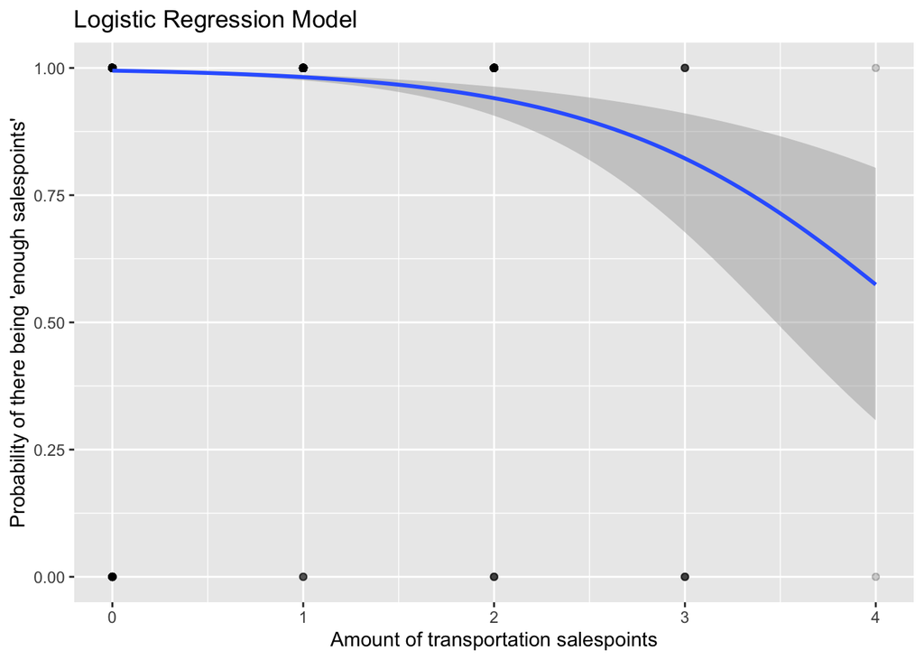

```r
#n_transport_salespoints logistic regression on the score
df_n_transport_2 %>%
  mutate(prob = ifelse(score == "0", 1, 0)) %>%
  ggplot(aes(n_transport_salespoints , prob)) +
  geom_point(alpha = 0.2) +
  geom_smooth(method = "glm", method.args = list(family = "binomial")) +
  labs(
    title = "Logistic Regression Model",
    x = "Amount of transportation salespoints",
    y = "Probability of there being 'enough salespoints'"
    )
```